# Palette tester v1.0

Giuseppe D’Agostino

[Back to the index page.](https://gdagstn.github.io/fileindex.html)

This is a set of 2 tools to check how a color palette performs in various scenarios. To map a continuous variable to a color palette it is important to use an ordered set of colors that is perceptually uniform, i.e. with linear changes in luminance. `ColorRampPalette` palettes are usually perceptually uniform, but may be slightly boring. Other color palettes that are widely used (e.g. rainbow palette) can exaggerate differences between close values due to their erratic luminance profile. The `viridis` package has 4 perceptually uniform palettes that are not just color ramps, and make for nice visualizations in heatmaps, heatscatters and other types of visualization where colors map to continuous variables. On the other hand, such a palette is ill suited for unique labels such as the ones we would use to identify different samples (barplots, boxplots) or clusters (PCA, tSNE, UMAP).

We first load the viridis library:

```r
require(viridis)
```

We then define the first function, `perceptually`, which shows the luminance and brightness profiles for the ordered set of colors in the palette, together with the palette itself and color names (or HEX values). The desaturate argument can be used to check for the same characteristics in a grayscale format, using the function `desaturate` from the `colorspace` [package](https://www.rdocumentation.org/packages/colorspace/versions/1.3-2).

```r
#' Perceptual profile of color palettes
#' Plots colors with their brightness and luminance values
#' @param colors vector of characters with the colors to plot
#' @param cex numeric indicating the text size for color labels
#' @param desaturate logical: should colors be desaturated (converted to grayscale)?
#' @return A plot of a color palette with their brightness and luminance values, the colors themselves and their color names. Color names are plot only if length(colors) <= 20, and dots are shown only if length(colors) <= 50.

perceptually <- function(colors, cex = 2, desaturate = F)

    {
        require(colorspace)
        if(desaturate == T)
        {
            colors = desaturate(colors)
        }

        l <- length(colors)
        lums <- rep(0,l)
        for (i in 1:l)
        {
            lums[i] <- col2rgb(colors[i])[1]*0.299 + col2rgb(colors[i])[2]*0.587 + col2rgb(colors[i])[3]*0.114
        }

        brightness <- rep(0,l)
        for (i in 1:l)
        {
            brightness[i] <- col2rgb(colors[i])[1]*0.2126 + col2rgb(colors[i])[2]*0.7152 + col2rgb(colors[i])[3]*0.0722
        }

        ytop <- max(range(c(-60,range(lums), range(brightness))) + 30)
        plot(
            x = 1:l,
            y = rep(-15,l),
            ylim = c(-60,ytop),
            cex = cex,
            pch = 15,
            col = colors,
            xaxt = "n",
            yaxt = "n",
            ylab = "luminance and brightness",
            xlab = NA,
            bty = "n",
            main = paste("Perceptual profile, n = ", l, sep = "")
            )
        lines(
            x = 1:l,
            y = lums
            )
        lines(
            x = 1:l,
            y = brightness,
            col = "gray"
            )
        if(l <= 50)
        {
            points(
                x = 1:l,
                y = lums,
                pch = 16,
                col = colors,
                )
            points(
                x = 1:l,
                y = brightness,
                pch = 17,
                col = colors
                )
            legend(
                "top",
                bty="n",
                lwd=1,
                col=c("black", "gray"),
                pch=c(16, 17),
                legend=c("Luminance", "Brightness")
                )
        }
        else if(l > 50)
        {
            legend(
                "top",
                bty="n",
                lwd=1,
                col=c("black", "gray"),
                legend=c("Luminance", "Brightness")
                )
        }

        ticks <- seq(0, max(lums), by = 20)
        axis(2, at=ticks, labels=ticks)
        if (l <= 20)
            {
                text(labels = colors, srt = 90, x = 1:l, y = -50, cex = 0.7)
            }

    }
```

Let’s look at the `perceptually` output of the viridis “C” palette:

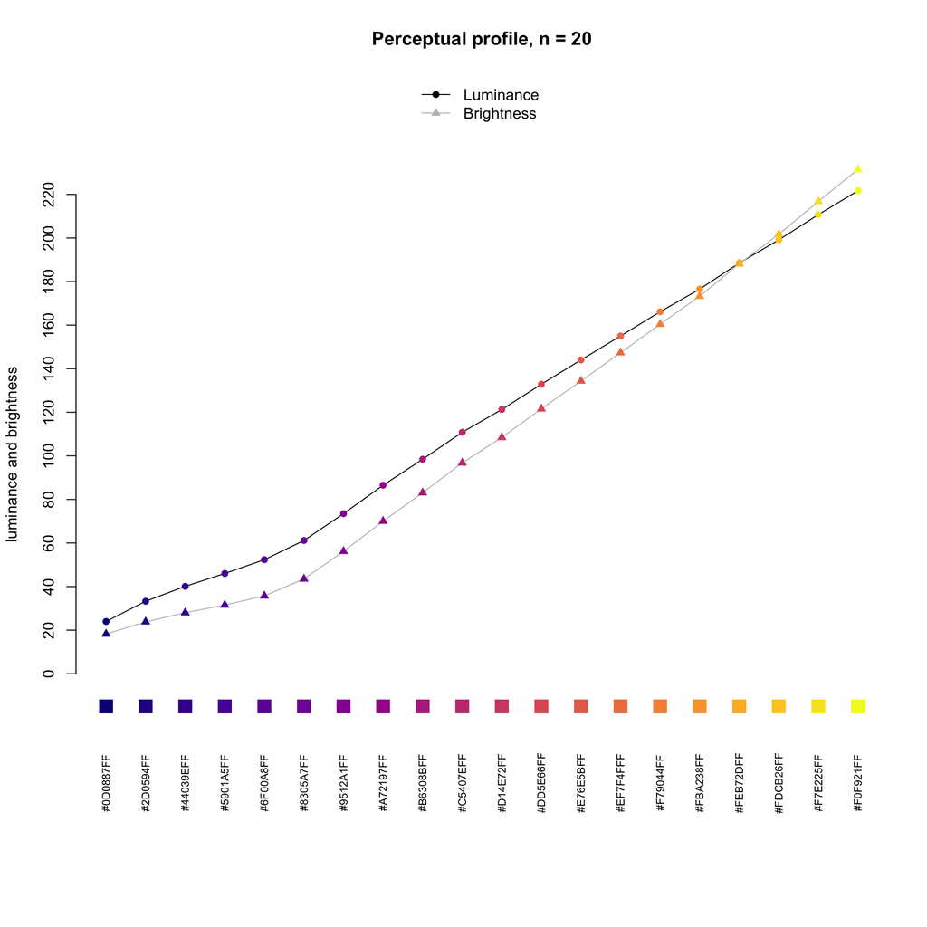

```r
perceptually(viridis(20, option ="C"))
```

And now with desaturation (notice how luminance and brightness are overlapping):

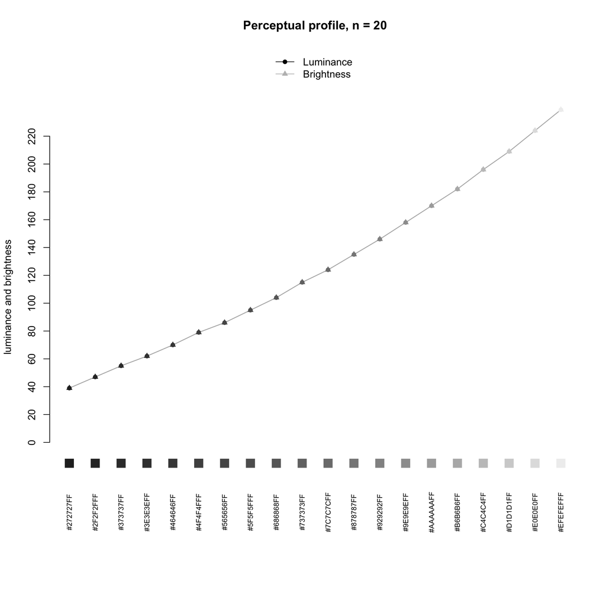

```r
perceptually(viridis(20, option ="C"), desaturate = T)
```

Let’s now look at the `perceptually` output of the rainbow palette:

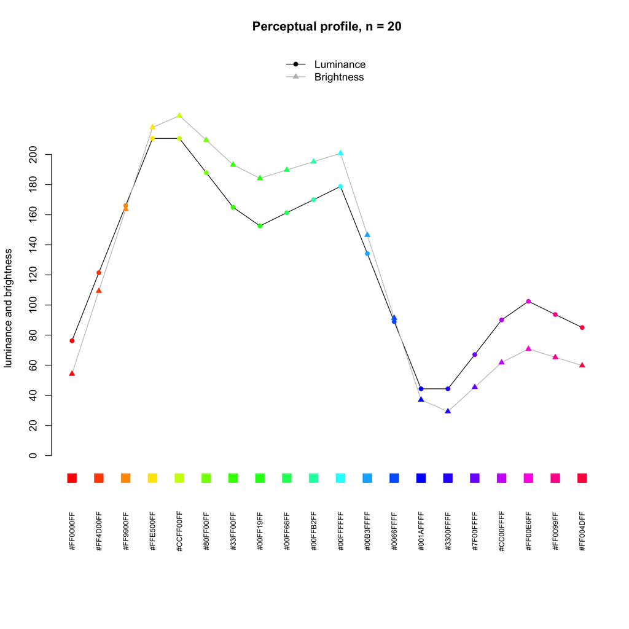

```r
perceptually(rainbow(n = 20))
```

And with desaturation:

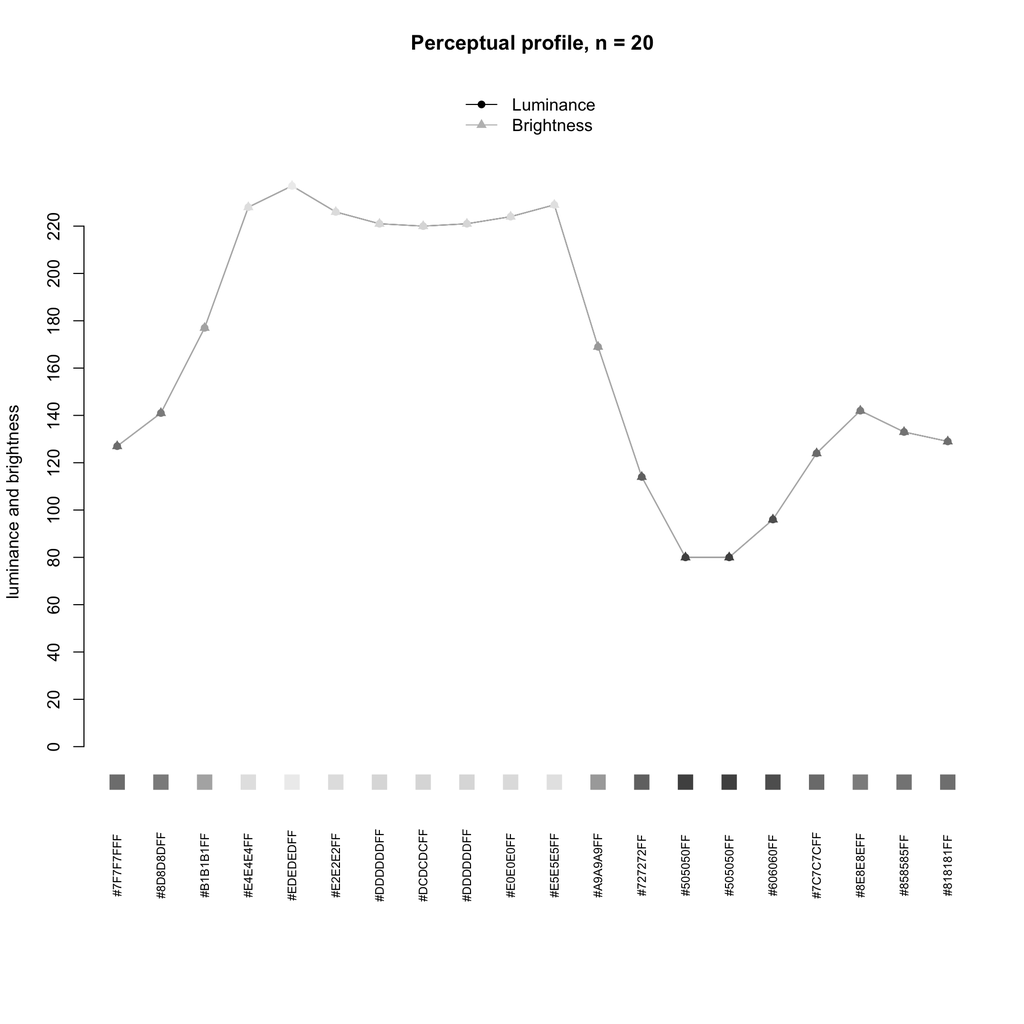

```r
perceptually(rainbow(n = 20), desaturate = T)
```

Even though perceptually uniform palettes are very important for continuous variables, they are not ideal for distinguishing samples in barplots, boxplots, line charts or in 2D representations in which clusters are important, such as tSNE plots from single cell data.

We write another function, `multiplottest`, that shows how a palette performs in various use cases using simulated data and real single cell data. This function simulates values for a barplot, a heatmap, some line graphs and uses a tSNE plot from a real single cell dataset. In the tSNE plot, clusters are artificially created by hierarchical clustering on the tSNE coordinates, so that we always have 1 cluster per color.

```r
#' Multi plot test for color palettes
#' A panel with 4 plots (barplot, line chart, heatmap and tSNE) coloured with a user-supplied palette
#' @param colors vector of characters with colors
#' @param randomize logical: should the order of colors in the palette be randomized? Only applies to barplot and line chart.
#' @return 4 plots with the supplied colors.

multiplottest <- function(colors, randomize = F)
{
    layout(matrix(1:4, nrow = 2))
    if(randomize == T)
    {
    barplot(sample(1:length(colors), length(colors)), col = colors[sample(1:length(colors), length(colors), replace = F)], border = NA)
    }
    else
    {
    barplot(sample(1:length(colors), length(colors)), col = colors, border = NA)
    }
    hmap = matrix(rep(0,length(colors)*length(colors)), ncol = length(colors))
    for(i in 1:length(colors)) hmap[,i] = runif(length(colors), i, i*3)
    hr <- hclust(as.dist(hmap), method="complete")
    hc <- hclust(as.dist(t(hmap)), method="complete")
    hm2 = as.matrix(hmap[hr$order, hc$order])
    image(t(as.matrix(hm2)), col = colors, xaxt = "n", yaxt = "n")
    plot(x = 1:length(colors), y = rep(10, length(colors)), col = colors[1], cex = 0, ylim = c(0, length(colors)+3), xlab = NA, ylab = NA)
    if(randomize == T)
    {
        randomcols = colors[sample(1:length(colors), length(colors))]
        for(i in 1:length(colors)) lines(x = 1:length(colors), y = runif(length(colors), i, i+2.5), col = randomcols[i], lwd = 2)
    } else {
        for(i in 1:length(colors)) lines(x = 1:length(colors), y = runif(length(colors), i, i+2.5), col = colors[i], lwd = 2)
    }
    tmp = dist(tsne)
    hc = hclust(tmp)
    cutt = cutree(hc, k = length(colors))
    dat = as.data.frame(cbind(tsne,cutt))
    plot(dat[,1], dat[,2], col = colors[dat[,3]], pch = 16, xlab = NA, ylab = NA)

}
```

We can see how viridis palettes perform well for heatmaps, but not for any other categorical variable

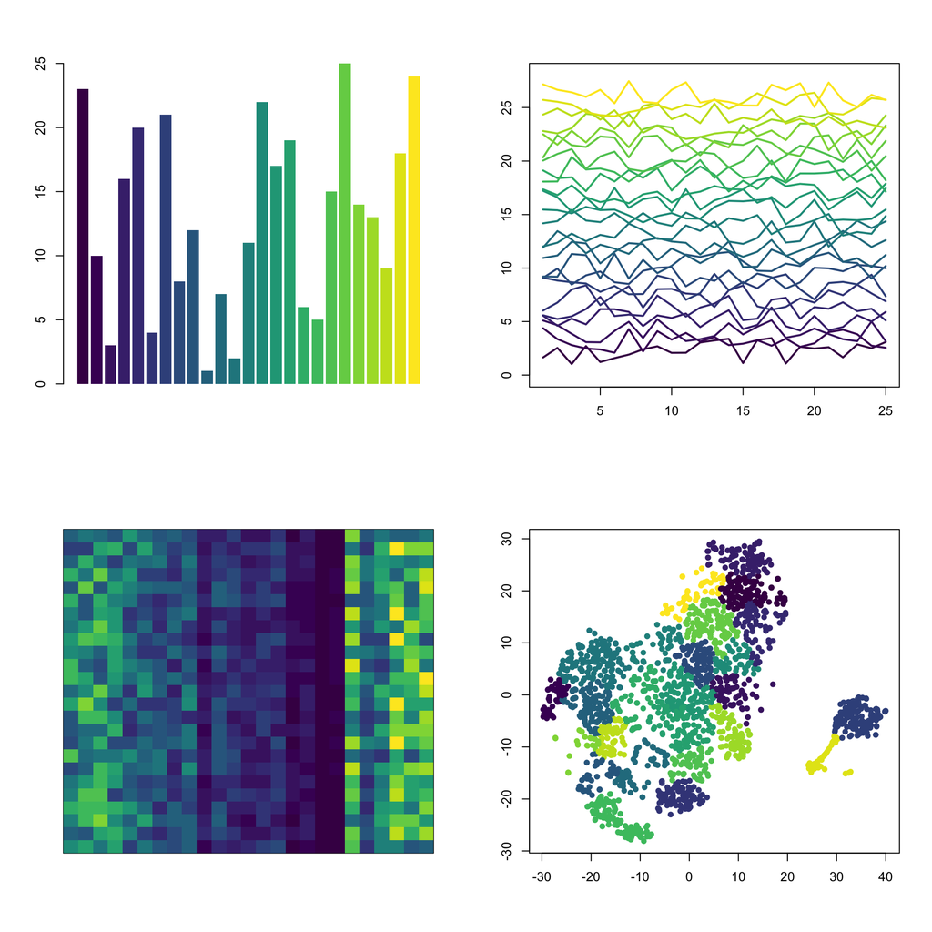

```r
multiplottest(viridis(25, option = "D"))
```

Whereas a unique palette (taken from [here](https://sashat.me/2017/01/11/list-of-20-simple-distinct-colors/)) is very good for categorical variables, but horrible for heatmaps:

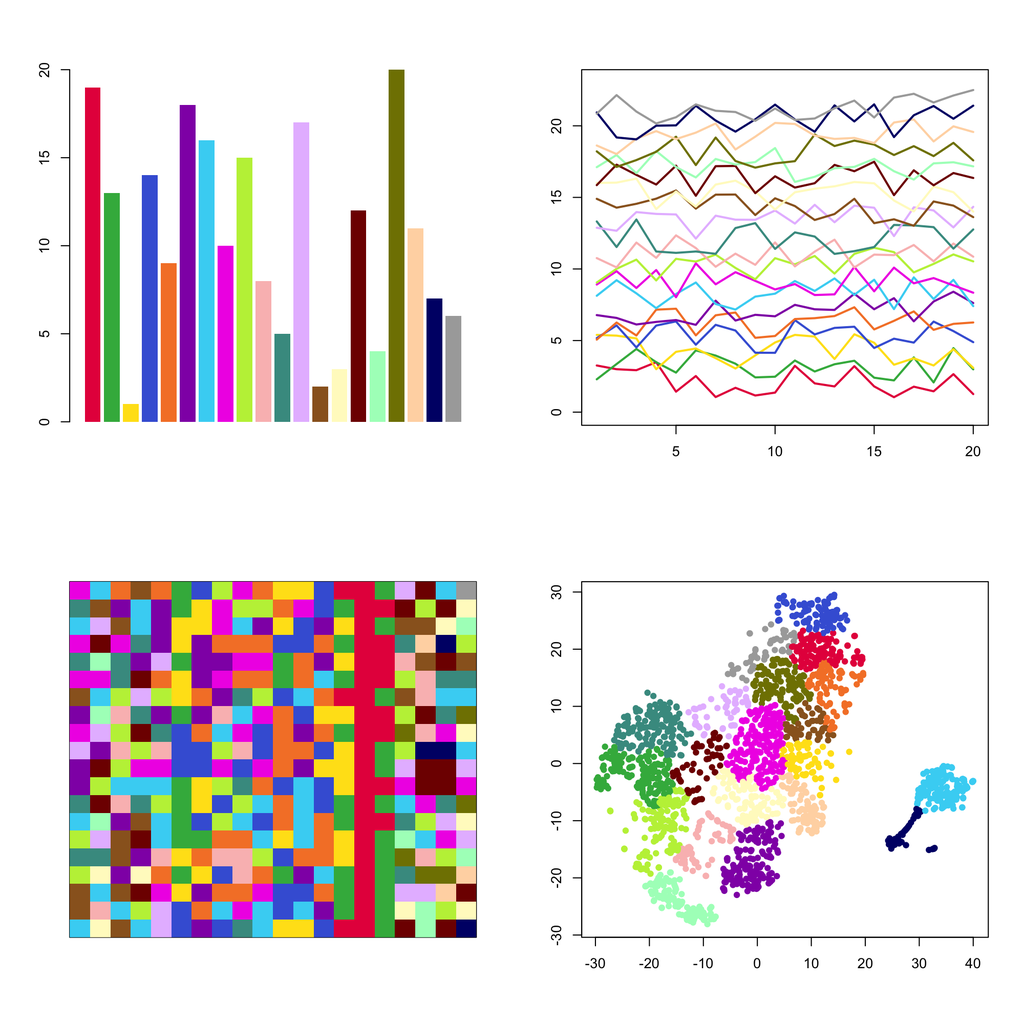

```r
uniquecols =c("#e6194B", "#3cb44b", "#ffe119", "#4363d8", "#f58231", "#911eb4", "#42d4f4", "#f032e6", "#bfef45", "#fabebe", "#469990", "#e6beff", "#9A6324", "#fffac8", "#800000", "#aaffc3", "#808000", "#ffd8b1", "#000075", "#a9a9a9")

multiplottest(uniquecols)
```

Notice that we removed black and white colors from the original palette.

Back to top  
[Back to the index page.](https://gdagstn.github.io/fileindex.html)